# Bristol Airbnb Analysis

Yoshiki Okada

2025-07-28

## **Introduction**

This report analyzes price patterns of Airbnb listings in Bristol using the listings.csv.gz dataset, which contains detailed information on individual properties. The dataset, published quarterly on the official Airbnb platform, is based on data from March.

Specifically, the analysis focuses on four key factors influence room prices (price) on Airbnb: location (neighbourhood_cleansed), room type (room_type), number of reviews (number_of_reviews), and review ratings (review_scores_rating).

This project demonstrates fundamental data analysis and visualization skills relevant to real-world business contexts.

## **Data Source**

The data used in this analysis is publicly available from Inside Airbnb, an independent website providing data on Airbnb listings in major cities worldwide.

The specific dataset used is the Bristol listings dataset for March, which can be downloaded [here](https://insideairbnb.com/get-the-data/).

This dataset is licensed under the Creative Commons Attribution 4.0 International License (CC BY 4.0). You can find the license details [here](https://creativecommons.org/licenses/by/4.0/).

Please cite as: “Get the Data.” Inside Airbnb, https://insideairbnb.com/get-the-data/. Accessed 28 July 2025.

## **Data Overview**

The listings.csv.gz dataset includes detailed information about 2772 properties in Bristol. For this analysis, the following variables were used:

- neighbourhood_cleansed: Indicates the location of the listings
- room_type: Type of room offered (e.g., Entire home/apt, Hotel room, Private room)
- price: Room price in local currency
- number_of_reviews: Total number of reviews the listing has received
- review_scores_rating: Average review score rating provided by guests

Other variables were not used in this analysis.

## **Data Cleaning and Preparation**

The dataset contains a large number of variables, many of which were irrelevant to this analysis and were therefore removed. Due to the vast number of variables, initial exploration was conducted using `skim()` to gain an overview of the data.

The “price” variable, one of the key variables for this analysis, was stored as a character string. The dollar signs were removed and the column was converted to numeric to prepare it for analysis.

Missing values (NA) in key variables (e.g., “price”, “review_scores_rating”) were excluded from this analysis due to the difficulty of imputing them. This exclusion process was primarily based on missing values in the “price” variable, considered the most critical.

During the exclusion process, an uneven distribution of missing values in “price” was observed across locations (the “neighbourhood_cleansed” variable). Given the inherent variation in listing counts among regions on Airbnb, completely eliminating this imbalance was deemed unfeasible. To address this, locations with fewer listings than the 25th percentile (32 listings) were grouped and labeled as “Other”.

For the review scores (“review_scores_rating”), missing values were also unevenly distributed across locations. A comparison of the data before and after excluding listings with missing prices revealed an increase in both the missing rate and regional imbalance in review scores. To mitigate regional bias, review scores with missing values were removed in conjunction with the exclusion of listings missing price data.

```r
airbnb_df <- read.csv("listings.csv")
```

```r
airbnb_rm <- airbnb_df %>%
  select(neighbourhood_cleansed, latitude, longitude, room_type, number_of_reviews, review_scores_rating, price)
```

```r
airbnb_rm_dollar <- airbnb_rm %>%
  mutate(price_num = gsub("\\$", "",price))

airbnb_rm_dollar$price_num <- as.numeric(airbnb_rm_dollar$price_num)
```

```r
grouped_airbnb <- airbnb_rm_dollar %>%
  group_by(neighbourhood_cleansed) %>%
  summarise(room_num = n(), .groups = "drop") %>%
  mutate(location_group = ifelse(room_num <= 32, "Other", as.character(neighbourhood_cleansed)))

grouped_airbnb_rm <- airbnb_rm_dollar %>%
  left_join(grouped_airbnb %>%
              select(neighbourhood_cleansed, location_group), by = "neighbourhood_cleansed")
```

```r
airbnb_cleaned_save <- grouped_airbnb_rm %>%
  na.omit()
```

```r
## A separate analysis dataset was derived from the cleaned data to exclude additional irrelevant entries, while preserving the original as a backup.

airbnb_use <- airbnb_cleaned_save %>%
  select(-c(neighbourhood_cleansed, price, latitude, longitude))
```

## **Explanation of Analytical Methods**

In this analysis, I performed graphical visualization and regression analysis for key variables that are thought to affect price - location, room type, number of reviews and review ratings.

### **Reasons for Selecting Each Variable:**

**Location:** It was assumed that factors such as land value and surrounding environment would be reflected in price settings.

**Room Type:** It was hypothesized that factors such as room size and maximum occupancy could affect pricing. Although privacy may also be a relevant factor, the current classification into “Entire home/apt”, “Hotel room”, and “Private room” does not provide sufficient detail to assess the degree of privacy accurately.

**Number of Reviews and Their Scores:** Guests are likely to consider not only the rating but also the number of reviews as a measure of credibility. A low number of reviews may reduce trust in the rating, while a high number may give a sense of reliability, potentially influencing the listed price.

### **Methods Used and Their Purposes:**

For both location and room type, visualizations using bar plots based on mean prices and simple linear regression analyses were conducted. Outliers were initially inspected using a threshold of twice the mean price to roughly identify extreme values. However, since these outliers were unevenly distributed and concentrated in specific categories, mechanically excluding them was deemed inappropriate. Therefore, rather than relying on boxplots, bar plots based on mean values were used to enhance readability and better represent the data distribution.

The linear regression of location vs. price aimed to capture general pricing trends by region, as the qualitative aspects embedded within location (e.g., accessibility, local popularity) are difficult to quantify.

The regression analysis of room type vs. price was performed using overall averages rather than separating by region, as regional segmentation would result in overly complex analysis.

For the number and rating of reviews, since the two variables are conceptually interrelated in how they affect guest decisions, a multiple linear regression approach was used instead of simple regression. Additionally, to visually confirm the interaction and trends, a heatmap was created.

### **Model Overview:**

These analyses aimed to explore the general relationships between price and selected variables using simple and multiple linear regression models, without constructing a comprehensive predictive model.

## **Results and Code**

In this section, I present the code and visualizations based on the previously described analytical methods. The results and interpretations follow each output accordingly.

Note: Regression outputs are omitted throughout this section for clarity and consistency, as they are lengthy and not visually interpretable. Key insights are summarized in the interpretation.

### **Location vs Price**

#### **Data Aggregation:**

The average price for each location was visualized using a bar chart with overall mean price.

```r
lvp_airbnb <- airbnb_use %>%
  group_by(location_group) %>%
  summarise(ave_price = mean(price_num, na.rm = TRUE))

total_ave_price = mean(lvp_airbnb$ave_price, na.rm = TRUE)
```

#### **Visualization: Graph**

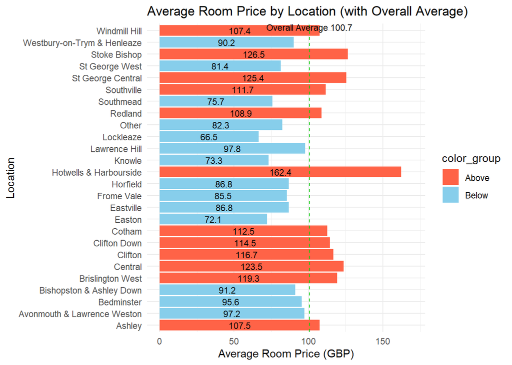

```r
lvp_airbnb$color_group <- ifelse(lvp_airbnb$ave_price > total_ave_price, "Above", "Below")

ggplot() +
  geom_col(data = lvp_airbnb, aes(x = factor(location_group), y = ave_price, fill = color_group)) +
  geom_text(data = lvp_airbnb, aes(x = factor(location_group), y = ave_price/2, label = paste0(round(ave_price, 1))),
            color = "black", size = 3) +
  geom_hline(yintercept = total_ave_price, linetype = "dashed", color = "green3") +
  annotate("text", x = Inf, y = total_ave_price, label = paste0("Overall Average ", round((total_ave_price), 1)), hjust = 0.5, vjust = 1, color = "black", size = 3) +
  coord_flip() +
  scale_y_continuous(labels = scales::comma,
                     breaks = seq(0, 200, by = 50),
                     limits = c(0, 170)) +
  scale_fill_manual(values = c("Above" = "tomato", "Below" = "skyblue")) +
  labs(title = "Average Room Price by Location (with Overall Average)",
       x = "Location",
       y = "Average Room Price (GBP)",
       ) +
  theme_minimal()
```

#### **Note:**

“Other” includes locations with fewer than 32 listings. Prices are displayed in GBP, based on the assumption that all listings are denominated in the local currency (UK). These explanations are provided here for clarity and will be omitted in subsequent visualizations.

#### **Brief Interpretation:**

Out of 26 areas (including “Other”), 12 showed average prices above the overall mean. Hotwells & Harbourside had the highest, at about 1.6 times the mean. This pricing pattern may be explained by the area’s advantageous location, offering convenient access to multiple major tourist attractions.

#### **Linear Regression Analysis:**

```r
model_lvp <- lm(price_num ~factor(location_group), data = airbnb_use)
```

A regression analysis using location as a predictor showed limited explanatory power (R² ≈ 4%), suggesting that location alone does not sufficiently explain price differences.

#### **Integrated Analysis and Discussion:**

The discrepancy between the visual trend and the weak statistical relationship may be attributed to unquantifiable factors such as neighborhood reputation, safety, the density of nearby accommodations, or other location-specific characteristics that are difficult to quantify and were not included in the model.

### **Room Type vs Price Analysis**

#### **Data Aggregation:**

The average price for each room type was visualized using a bar chart.

```r
rvp_airbnb <- airbnb_use %>%
  group_by(room_type) %>%
  summarise(ave_price = mean(price_num, na.rm = TRUE))
```

#### **Visualization: Graph**

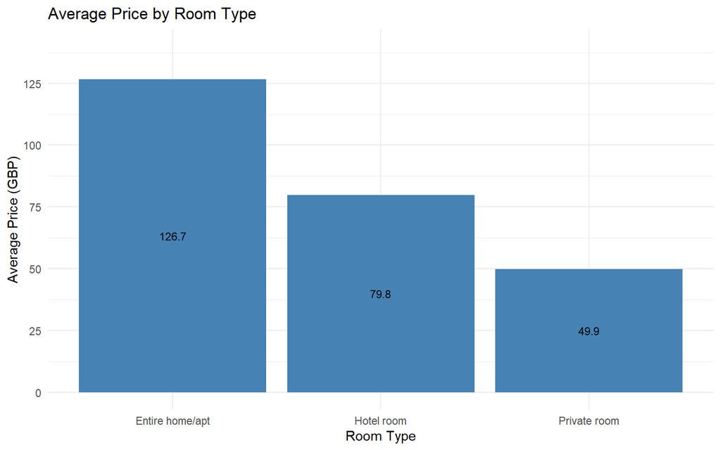

```r
ggplot(data = rvp_airbnb, aes(x = factor(room_type), y = ave_price)) +
  geom_col(fill = "steelblue") +
  geom_text(data = rvp_airbnb, aes(x = factor(room_type), y = ave_price/2, label = paste0(round(ave_price, 1))), color = "black", size = 3) +
  scale_y_continuous(labels = scales::comma,
                     breaks = seq(0, 150, by = 25),
                     limits = c(0, 140)) +
  labs(title = "Average Price by Room Type",
       x = "Room Type",
       y = "Average Price (GBP)",) +
  theme_minimal()
```

#### **Note:**

The “hotel room” category has only 4 listings in the dataset, and the average price shown here may not be representative.

#### **Brief Interpretation:**

Entire homes/apartments averaged £126.7, reflecting their size and capacity. While hotel rooms (£79.8) were about 1.6 times more expensive than private rooms (£49.9), this is likely due to the very small number of observations (n = 4), and may not reflect the actual market trend.

#### **Linear Regression Analysis:**

```r
model_rvp <- lm(price_num ~factor(room_type), data = airbnb_use)
```

A regression analysis using room as a predictor showed limited explanatory power (R² ≈ 17.5%), suggesting that room type alone does not sufficiently explain price differences.

#### **Integrated Analysis and Discussion:**

The discrepancy between the visual trend and the weak statistical relationship may be attributed to unquantifiable factors such as property condition, amenities, and host pricing strategies. They likely play a significant role, making it difficult for a simple model to capture the complexity observed in the visual trends.

Given the low explanatory power of single-variable regressions for room type and location, and the presence of many unquantifiable factors, further multivariate regression involving these variables was deemed unnecessary. The analysis proceeds with a multiple regression focusing on review count and scores.

### **Number of Reviews and Their Scores vs Price**

#### **Data Aggregation:**

Number of reviews and their scores were grouped into quartiles, and the average room price was calculated for each combination of these groups.

```r
rnsvp_airbnb_use <- airbnb_use %>%
  mutate(review_num_group = cut(number_of_reviews,
                                breaks = quantile(number_of_reviews, probs = seq(0, 1, 0.25), na.rm = TRUE),
                                include.lowest = TRUE,
                                labels = c("Very Few", "Few", "Moderate", "Many")),
         review_score_group = cut(review_scores_rating,
                                  breaks = quantile(review_scores_rating, probs = seq(0, 1, 0.25), na.rm = TRUE),
                                  include.lowest = TRUE,
                                  labels = c("Low", "Fair", "Good", "High")))

tile_rnsvp <- rnsvp_airbnb_use %>%
  group_by(review_num_group, review_score_group) %>%
  summarise(ave_price = mean(price_num, na.rm = TRUE), .groups = "drop")
```

#### **Visualization: Graph**

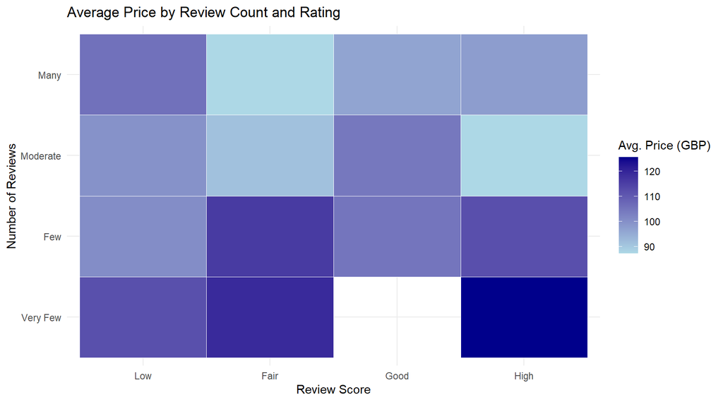

```r
ggplot(data = tile_rnsvp, aes(x = review_score_group, y = review_num_group, fill = ave_price)) +
  geom_tile(color = "white") +
  scale_fill_gradient(low = "lightblue", high = "blue4", name = "Avg. Price (GBP)") +
  labs(
    title = "Average Price by Review Count and Rating",
    x = "Review Score",
    y = "Number of Reviews",
    ) +
  theme_minimal()
```

#### **Note:**

“Number of Reviews” groups (“Very Few”, “Few”, “Moderate”, “Many”) and “Review Scores” groups (“Low”, “Fair”, “Good”, “High”) were created by dividing their respective distributions into quartiles (0.25 increments) to reduce the impact of skewed data.

#### **Brief Interpretation:**

The heatmap indicates that higher average prices are found in listings labeled with “Fair” review scores and “Very Few” or “Few” reviews, as well as those labeled with “High” review scores and “Very Few” reviews. Conversely, lower average prices occur in listings labeled with “Fair” review scores and “Moderate” or “Many” reviews, and with “High” review scores and “Moderate” reviews.

These patterns suggest that, although number of reviews and review scores may influence price, no clear or consistent relationship is evident from the data.

#### **Multiple Regression Analysis:**

```r
model_rnsvp <- lm(price_num ~ factor(review_score_group) + factor(review_num_group), data = rnsvp_airbnb_use)
```

A regression analysis using number of reviews and their scores as predictors showed limited explanatory power (R² ≈ 1.3%), suggesting that these variables do not sufficiently explain price differences.

#### **Integrated Analysis and Discussion:**

Based on the results of the foregoing analyses, it can be concluded that the number of reviews and review scores do not constitute significant determinants of price, contrary to initial expectations. Although these variables may potentially influence other factors such as host revenue, booking rates, or reservation volume, they do not serve as meaningful predictors for the purpose of analyzing price trends in the this analysis.

## **Conclusion**

### **Analytical Summary and Insights:**

- Visualizations revealed clear pricing trends across location and room type categories. For instance, areas like Hotwells & Harbourside exhibited significantly higher average prices, and entire homes/apartments were priced higher than other room types. It should be noted, however, that the “hotel room” category contained only a few listings, making its average price potentially unreliable.
- While the regression models showed limited explanatory power—location (R² ≈ 4%), room type (R² ≈ 17.5%), and review metrics (R² ≈ 1.3%)—the visual trends observed in certain neighborhoods may still hold practical implications for host pricing strategies, particularly in areas with advantageous locations or perceived desirability.
- The discrepancy between visual trends and statistical models highlights the presence of additional, unquantifiable variables—such as neighborhood reputation, host strategies, and property conditions—that likely play a substantial role in determining prices.
- Multivariate regression was applied only to review metrics, given that location and room type had already demonstrated limited explanatory power individually. However, this also yielded weak results, reinforcing the notion that Airbnb pricing is influenced by a complex interplay of factors not fully captured by the dataset.

### **Implications:**

- Superficial trends may be misleading if not supported by statistical rigor. Visualizations alone suggest price differences tied to location and room type, but regression analysis shows that these impressions may not hold when tested quantitatively.
- Pricing decisions in Airbnb are likely shaped by a combination of subjective and unmeasured variables—such as property aesthetics, personalized host services, or seasonal dynamics—that cannot be easily modeled using standard datasets.
- For stakeholders, including hosts and platform analysts, this underscores the importance of considering qualitative aspects alongside data-driven insights when setting or evaluating price structures.
- This raises a broader question: To what extent can pricing in peer-to-peer marketplaces be effectively modeled without incorporating dynamic and personalized variables? Traditional regression models may fail to capture the fluid and idiosyncratic nature of such platforms. Future analyses might benefit from incorporating time-sensitive data, host-specific profiles, or even text-based review sentiment to improve explanatory power.

### **Limitations:**

- Although the dataset contains variables like bedroom count and amenities, many potentially important factors—such as proximity to tourist attractions, neighborhood characteristics, or host services—were excluded due to difficulties in consistent quantification and the risk of subjective bias.
- Temporal variables, such as booking season or listing age, were not included in the analysis, potentially overlooking short-term or time-sensitive pricing effects.
- The “hotel room” category included only four listings, which limited the reliability of any conclusions drawn about this room type.
- Categorical groupings (e.g., room type or review labels) may oversimplify nuanced differences, and the aggregation method may have masked variability within groups.
- Outlier handling was limited, and some high-price listings with atypical characteristics may have distorted overall trends despite visual filtering.

### **Future Work:**

- Incorporate additional features such as amenities, exact location coordinates, property size, and photos using NLP or computer vision techniques to better quantify listing characteristics.
- Apply time-series or panel data models to examine price dynamics across different periods or repeat listings.
- Conduct cluster analysis to identify natural groupings of listings based on multiple variables and explore whether these clusters correspond to meaningful pricing segments.
- Explore qualitative factors, such as host experience or guest satisfaction, potentially through sentiment analysis of reviews, to supplement numerical data with richer insights.